# Project2-EDA/logit-Aspen

Aspen Saplan

2026-04-24

# How does multiple attacks, weapon type, attack type, month of attack, or region of attack influence whether a terrorist attack causes property damage in 2019?

## Author of this section: Aspen Saplan

## Variable Key:

#### Property:

0 = No

1 = Yes

#### AttackType1:

1 = ASSASSINATION

2 = ARMED ASSAULT

3 = BOMBING/EXPLOSION

4 = HIJACKING

5 = HOSTAGE TAKING (BARRICADE INCIDENT)

6 = HOSTAGE TAKING (KIDNAPPING)

7 = FACILITY / INFRASTRUCTURE ATTACK

8 = UNARMED ASSAULT

9 = UNKNOWN

#### WeaponType1:

1 = Biological

2 = Chemical

3 = Radiological

4 = Nuclear

5 = Firearms

6 = Explosives

7 = Fake Weapons

8 = Incendiary

9 = Melee

10 = Vehicle

11 = Sabotage Equipment

12 = Other

13 = Unknown

#### Multiple:

0 = No

1 = Yes

#### Month:

1 = Jan

2 = Feb

3 = Mar

4 = April

5 = May

6 = June

7 = July

8 = Aug

9 = Sep

10 = Oct

11 = Nov

12 = Dec

#### Region:

1 = North America

2 = Central America & Caribbean

3 = South America

4 = East Asia

5 = Southeast Asia

6 = South Asia

7 = Central Asia

8 = Western Europe

9 = Eastern Europe

10 = Middle East & North Africa

11 = Sub-Saharan Africa

12 = Australasia & Oceania

## Set up of terror2019 dataset:

Multiple attacks variable represents if the record was one singular terrorist attack or if there were multiple combined that represent one terrorist attack. The weapon type variable represents what type of weapon was used to perform the terrorist attack. The month of attack variable represents what month the terrorist attack occurred in. The region variable represents the region that the terrorist attack took place in. The property variable is the dependent variable that will be examined and represents whether there was property damage or there was no property damage caused by this terrorist attack. All of these variables are of the type categorical variable, so the first thing that must be done is as factoring them so that r studio can represent them correctly.

```r
terror2019 = read.csv("TerrorData-2019.csv")
# If other datasets are used and include more than years 2019
# terror2019 = terror2019[terror2019$iyear == 2019, ]
terror2019 = terror2019[, c("property", "multiple", "weaptype1", "attacktype1", "imonth", "region")]
terror2019 = terror2019[terror2019$property != -9 & !is.na(terror2019$property),]
terror2019$property = as.factor(terror2019$property)
terror2019$multiple = as.factor(terror2019$multiple)
terror2019$weaptype1 = as.factor(terror2019$weaptype1)
terror2019$attacktype1 = as.factor(terror2019$attacktype1)
terror2019$imonth= as.factor(terror2019$imonth)
terror2019$region = as.factor(terror2019$region)
str(terror2019)
```

```
## 'data.frame':    6496 obs. of  6 variables:
##  $ property   : Factor w/ 2 levels "0","1": 2 2 1 1 2 1 1 2 1 1 ...
##  $ multiple   : Factor w/ 2 levels "0","1": 1 1 1 1 1 1 1 1 1 1 ...
##  $ weaptype1  : Factor w/ 10 levels "1","2","5","6",..: 4 4 3 3 4 3 3 3 4 3 ...
##  $ attacktype1: Factor w/ 9 levels "1","2","3","4",..: 3 1 2 2 1 2 2 2 3 1 ...
##  $ imonth     : Factor w/ 12 levels "1","2","3","4",..: 1 1 1 1 1 1 1 1 1 1 ...
##  $ region     : Factor w/ 12 levels "1","2","3","4",..: 6 5 5 6 5 6 11 8 6 1 ...
```

## Balance Check:

The next part of exploratory data analysis that is looked at is the ratio of zeros and ones in the property variable in order to know if this variable is balanced. Which as seen this variable is about fifty four percent no property damage and forty six percent yes property damage. Which is a pretty good balance of both yes and no values indicating that this is a good dependent variable choice for logistic regression modelling.

Number of records in 2019 with either property damage or no property damage:

```r
total = nrow(terror2019)
total
```

```
## [1] 6496
```

Number of records in 2019 without property damage:

```r
npd = sum(terror2019$property == 0)
npd
```

```
## [1] 3523
```

Number of records in 2019 with property damage:

```r
pd = sum(terror2019$property == 1)
pd
```

```
## [1] 2973
```

Percentage of records without property damage:

```r
(npd/total)
```

```
## [1] 0.5423337
```

Percentage of records with property damage:

```r
(pd/total)
```

```
## [1] 0.4576663
```

## EDA using Bar Charts:

As seen below are all the bar charts that represent the number of property damage compared to each potential covariate. The red bars represent no property damage, while the purple bars represent yes property damage.

For multiple terrorist attacks, no property damage is favored for single terrorist attacks, while yes property damage is favored for multiple terrorist attacks. Although, the single terrorist attack overall has more values then multiple terrorist attacks.

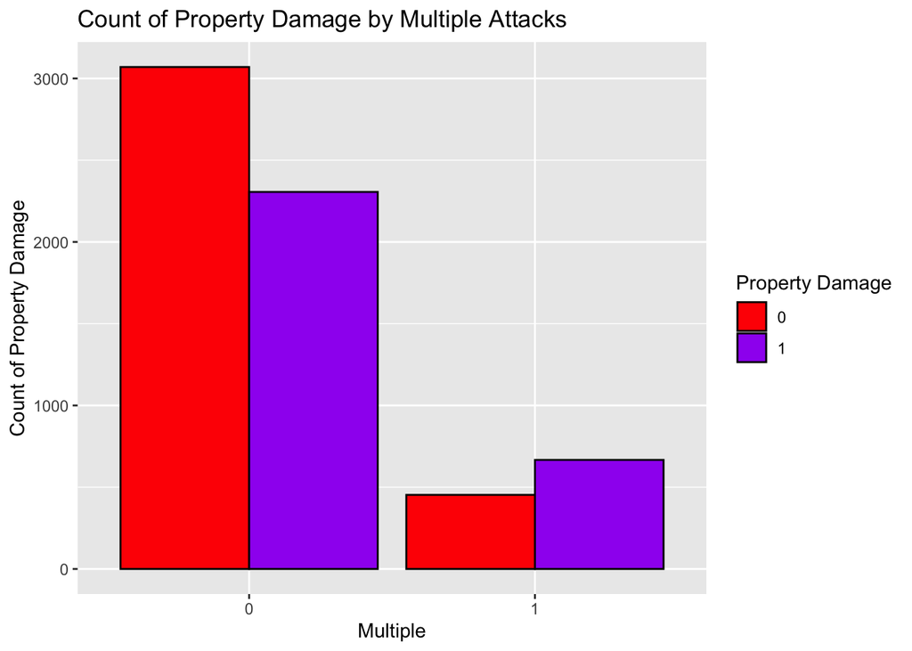

```r
library(ggplot2)
ggplot(terror2019, aes(x = multiple, fill = property)) +
  geom_bar(position = "dodge", color = "black")+
  scale_fill_manual(values = c(
    "1" = "purple",
    "0" = "red"
  ))+
  labs(title = "Count of Property Damage by Multiple Attacks",
    x = "Multiple",
    y = "Count of Property Damage",
    fill = "Property Damage")
```

The weapon type variable shows a mix of having more yes property damage and no property damage. What is interesting though is the insight on which weapons are used more often in 2019 for a terrorist attack. Overall, weapon five, six, eight, and thirteen make up the majority of weapon types used compared to all the rest. Some weapon types did not even occur in 2019 such as weapon three and four.

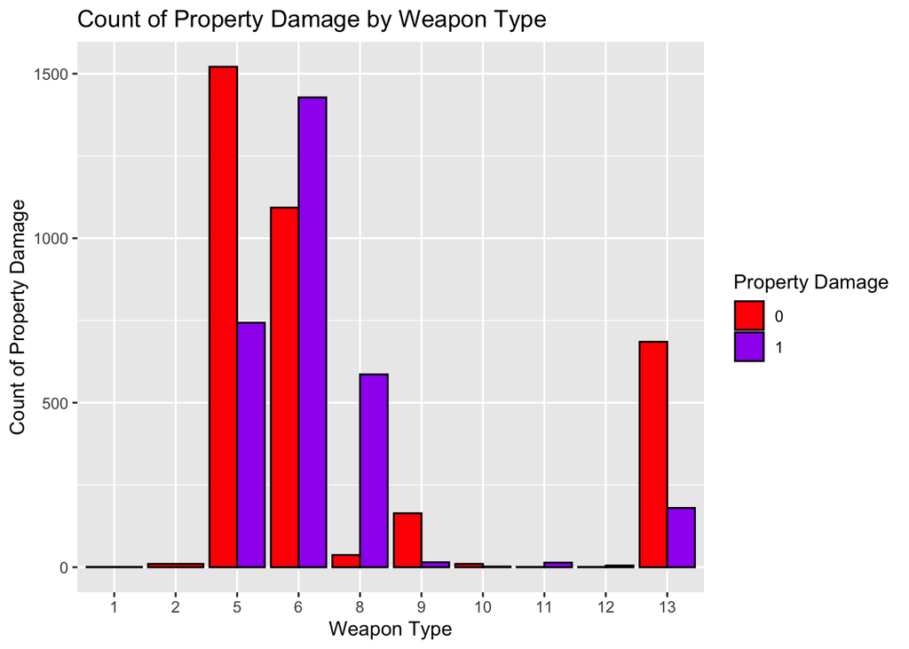

```r
library(ggplot2)
ggplot(terror2019, aes(x = weaptype1, fill = property)) +
  geom_bar(position = "dodge", color = "black")+
  scale_fill_manual(values = c(
    "1" = "purple",
    "0" = "red"
  ))+
  labs(title = "Count of Property Damage by Weapon Type",
    x = "Weapon Type",
    y = "Count of Property Damage",
    fill = "Property Damage")
```

The attack type variable shows similar results to the weapon type variable in the sense that some attacks caused more property damage then not. While some attacks caused more no property damage than actual property damage.

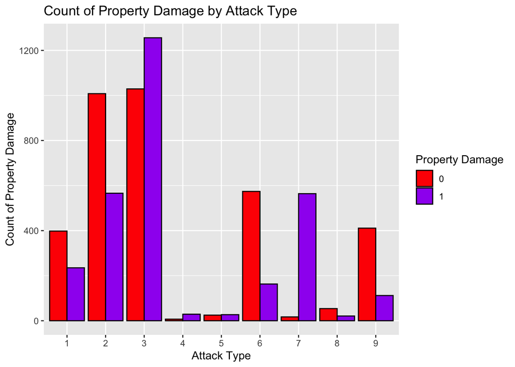

```r
library(ggplot2)
ggplot(terror2019, aes(x = attacktype1, fill = property)) +
  geom_bar(position = "dodge", color = "black")+
  scale_fill_manual(values = c(
    "1" = "purple",
    "0" = "red"
  ))+
  labs(title = "Count of Property Damage by Attack Type",
    x = "Attack Type",
    y = "Count of Property Damage",
    fill = "Property Damage")
```

The month of attack variable has pretty similar results across each month. Some months such as month twelve or month four have a spike in no property damage, while most of the other months have equal amounts of yes property damage and no property damage.

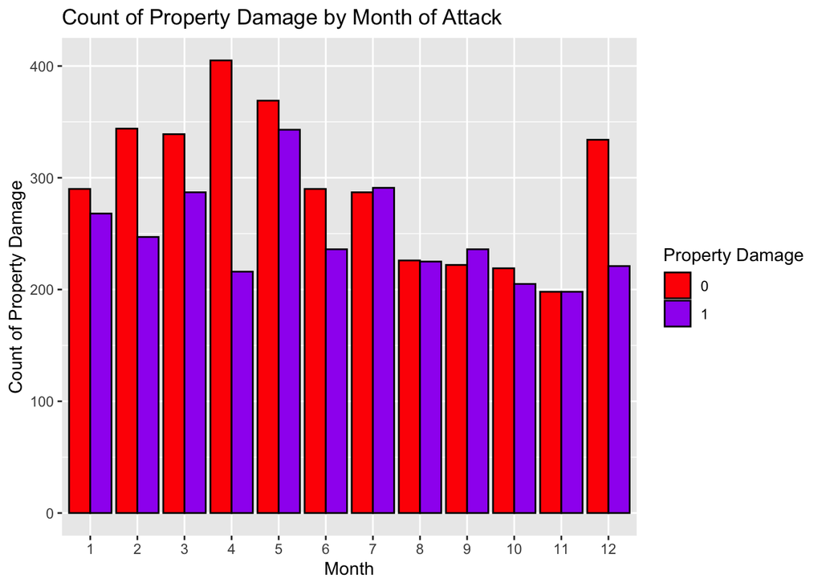

```r
library(ggplot2)
ggplot(terror2019, aes(x = imonth, fill = property)) +
  geom_bar(position = "dodge", color = "black")+
  scale_fill_manual(values = c(
    "1" = "purple",
    "0" = "red"
  ))+
  labs(title = "Count of Property Damage by Month of Attack",
    x = "Month",
    y = "Count of Property Damage",
    fill = "Property Damage")
```

The region variable shows that some regions have a large amount of both no property damage and yes property damage such as regions six, ten, and eleven. While the other regions have very little amount of terrorist attacks as a whole such as month four or twelve.

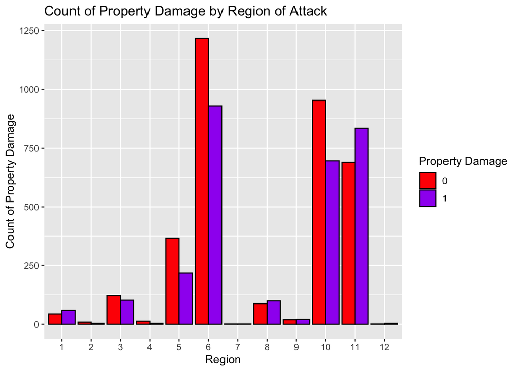

```r
library(ggplot2)
ggplot(terror2019, aes(x = region, fill = property)) +
  geom_bar(position = "dodge", color = "black")+
  scale_fill_manual(values = c(
    "1" = "purple",
    "0" = "red"
  ))+
  labs(title = "Count of Property Damage by Region of Attack",
    x = "Region",
    y = "Count of Property Damage",
    fill = "Property Damage")
```

## Hypothesis Testing:

The next step of exploratory data analysis used is the hypothesis test on each potential covariate and the dependent variable or property. Since all the covariates are categorical variable types and property is a categorical variable type a chi squared test of independence can be used for all of them. Each null hypothesis is that the potential covariate and the property variable are independent of each other. Each alternative hypothesis is that the potential covariate and the property variable are not independent of each other. The alpha value that will be accepted is 0.05.

Null Hypothesis: Multiple attacks and property damage are independent

Alternative Hypothesis: Multiple attacks and property damage are not independent

Alpha: 0.05

```r
library(ezids)
contableM = table(terror2019$property, terror2019$multiple)
xkabledply(contableM, title="Contingency table for property and multiple within dataset")
```

Contingency table for property and multiple within dataset

|  | 0 | 1 |
| --- | --- | --- |
| 0 | 3070 | 453 |
| 1 | 2306 | 667 |

```r
chitestM = chisq.test(contableM)
chitestM
```

```
##
##  Pearson's Chi-squared test with Yates' continuity correction
##
## data:  contableM
## X-squared = 102.97, df = 1, p-value < 2.2e-16
```

Null Hypothesis: Weapon type and property damage are independent

Alternative Hypothesis: Weapon type and property damage are not independent

Alpha: 0.05

```r
library(ezids)
contableW = table(terror2019$property, terror2019$weaptype1)
xkabledply(contableW, title="Contingency table for property and weapon type within dataset")
```

Contingency table for property and weapon type within dataset

|  | 1 | 2 | 5 | 6 | 8 | 9 | 10 | 11 | 12 | 13 |
| --- | --- | --- | --- | --- | --- | --- | --- | --- | --- | --- |
| 0 | 1 | 10 | 1521 | 1093 | 37 | 164 | 10 | 1 | 1 | 685 |
| 1 | 0 | 0 | 743 | 1428 | 586 | 15 | 2 | 14 | 5 | 180 |

```r
chitestW = chisq.test(contableW)
chitestW
```

```
##
##  Pearson's Chi-squared test
##
## data:  contableW
## X-squared = 1206.9, df = 9, p-value < 2.2e-16
```

Null Hypothesis: Attack type and property damage are independent

Alternative Hypothesis: Attack type and property damage are not independent

Alpha: 0.05

```r
library(ezids)
contableA = table(terror2019$property, terror2019$attacktype1)
xkabledply(contableA, title="Contingency table for property and attack type within dataset")
```

Contingency table for property and attack type within dataset

|  | 1 | 2 | 3 | 4 | 5 | 6 | 7 | 8 | 9 |
| --- | --- | --- | --- | --- | --- | --- | --- | --- | --- |
| 0 | 398 | 1008 | 1029 | 7 | 25 | 574 | 17 | 54 | 411 |
| 1 | 235 | 566 | 1256 | 29 | 27 | 163 | 564 | 21 | 112 |

```r
chitestA = chisq.test(contableA)
chitestA
```

```
##
##  Pearson's Chi-squared test
##
## data:  contableA
## X-squared = 1093.1, df = 8, p-value < 2.2e-16
```

Null Hypothesis: Month of attack and property damage are independent

Alternative Hypothesis: Month of attack and property damage are not independent

Alpha: 0.05

```r
library(ezids)
contableMO = table(terror2019$property, terror2019$imonth)
xkabledply(contableMO, title="Contingency table for property and month of attack within dataset")
```

Contingency table for property and month of attack within dataset

|  | 1 | 2 | 3 | 4 | 5 | 6 | 7 | 8 | 9 | 10 | 11 | 12 |
| --- | --- | --- | --- | --- | --- | --- | --- | --- | --- | --- | --- | --- |
| 0 | 290 | 344 | 339 | 405 | 369 | 290 | 287 | 226 | 222 | 219 | 198 | 334 |
| 1 | 268 | 247 | 287 | 216 | 343 | 236 | 291 | 225 | 236 | 205 | 198 | 221 |

```r
chitestMO = chisq.test(contableMO)
chitestMO
```

```
##
##  Pearson's Chi-squared test
##
## data:  contableMO
## X-squared = 62.934, df = 11, p-value = 2.631e-09
```

Null Hypothesis: Region of attack and property damage are independent

Alternative Hypothesis: Region of attack and property damage are not independent

Alpha: 0.05

```r
library(ezids)
contableR = table(terror2019$property, terror2019$region)
xkabledply(contableR, title="Contingency table for property and region of attack within dataset")
```

Contingency table for property and region of attack within dataset

|  | 1 | 2 | 3 | 4 | 5 | 6 | 7 | 8 | 9 | 10 | 11 | 12 |
| --- | --- | --- | --- | --- | --- | --- | --- | --- | --- | --- | --- | --- |
| 0 | 44 | 9 | 121 | 13 | 367 | 1218 | 1 | 88 | 19 | 953 | 689 | 1 |
| 1 | 60 | 4 | 102 | 4 | 219 | 930 | 1 | 99 | 21 | 695 | 834 | 4 |

```r
chitestR = chisq.test(contableR)
chitestR
```

```
##
##  Pearson's Chi-squared test
##
## data:  contableR
## X-squared = 97.637, df = 11, p-value = 5.238e-16
```

Each potential covariate being multiple, weapon type, attack type, region, month have p-values that are less than our set alpha value. This indicates that for each chi squared test we can reject the null hypotheses, indicating that each potential covariate is not independent of property.

## Logistic Regression Model 1:

### glm(property ~ multiple + attacktype1 + imonth + region + weaptype1, data = terror2019, family = binomial):

```r
library(stats)
model1 = glm(property ~ multiple + attacktype1 + imonth + region + weaptype1, data = terror2019, family = binomial)
summary(model1)
```

```
##
## Call:
## glm(formula = property ~ multiple + attacktype1 + imonth + region +
##     weaptype1, family = binomial, data = terror2019)
##
## Coefficients:
##               Estimate Std. Error z value Pr(>|z|)
## (Intercept)  -13.57750  535.41149  -0.025 0.979769
## multiple1      0.38131    0.08089   4.714 2.43e-06 ***
## attacktype12  -0.04589    0.11388  -0.403 0.686948
## attacktype13  -0.68289    0.16132  -4.233 2.30e-05 ***
## attacktype14   2.36842    0.45841   5.167 2.38e-07 ***
## attacktype15   0.85412    0.32446   2.632 0.008477 **
## attacktype16  -0.40271    0.14480  -2.781 0.005417 **
## attacktype17   3.08253    0.29707  10.377  < 2e-16 ***
## attacktype18   1.23147    0.49380   2.494 0.012635 *
## attacktype19   0.38645    0.22941   1.685 0.092074 .
## imonth2       -0.44282    0.13850  -3.197 0.001388 **
## imonth3       -0.15989    0.13510  -1.184 0.236595
## imonth4       -0.52143    0.13645  -3.821 0.000133 ***
## imonth5       -0.17162    0.13051  -1.315 0.188520
## imonth6       -0.21810    0.13948  -1.564 0.117905
## imonth7        0.02229    0.13622   0.164 0.870041
## imonth8        0.03310    0.14580   0.227 0.820435
## imonth9       -0.10503    0.14739  -0.713 0.476097
## imonth10      -0.02187    0.15105  -0.145 0.884879
## imonth11      -0.09682    0.15127  -0.640 0.522125
## imonth12      -0.42812    0.14223  -3.010 0.002613 **
## region2       -0.98774    0.68379  -1.445 0.148598
## region3       -0.70333    0.32005  -2.198 0.027983 *
## region4       -2.05773    0.85680  -2.402 0.016322 *
## region5       -0.83196    0.29494  -2.821 0.004790 **
## region6       -0.77593    0.28647  -2.709 0.006757 **
## region7       -1.25480    1.81630  -0.691 0.489656
## region8       -1.19443    0.33735  -3.541 0.000399 ***
## region9       -0.40423    0.48106  -0.840 0.400747
## region10      -0.77722    0.28787  -2.700 0.006935 **
## region11       0.09065    0.28680   0.316 0.751952
## region12       0.01989    1.41708   0.014 0.988801
## weaptype12    -0.60458  557.06459  -0.001 0.999134
## weaptype15    13.42617  535.41140   0.025 0.979994
## weaptype16    15.29128  535.41142   0.029 0.977216
## weaptype18    15.56872  535.41142   0.029 0.976802
## weaptype19    11.37402  535.41133   0.021 0.983051
## weaptype110   10.94993  535.41186   0.020 0.983683
## weaptype111   13.76862  535.41247   0.026 0.979484
## weaptype112   15.32314  535.41238   0.029 0.977168
## weaptype113   12.60205  535.41143   0.024 0.981222
## ---
## Signif. codes:  0 '***' 0.001 '**' 0.01 '*' 0.05 '.' 0.1 ' ' 1
##
## (Dispersion parameter for binomial family taken to be 1)
##
##     Null deviance: 8958.7  on 6495  degrees of freedom
## Residual deviance: 7069.4  on 6455  degrees of freedom
## AIC: 7151.4
##
## Number of Fisher Scoring iterations: 12
```

### Accuracy:

```r
probs = predict(model1, type = "response")
pred = ifelse(probs > 0.5, 1, 0)
table(Predicted = pred, Actual= terror2019$property)
```

```
##          Actual
## Predicted    0    1
##         0 2633  995
##         1  890 1978
```

```r
mean(pred == terror2019$property)
```

```
## [1] 0.7098214
```

### ROC and AUC:

```r
library(pROC)
probs = predict(model1, type = "response")
r = roc(terror2019$property, probs)
```

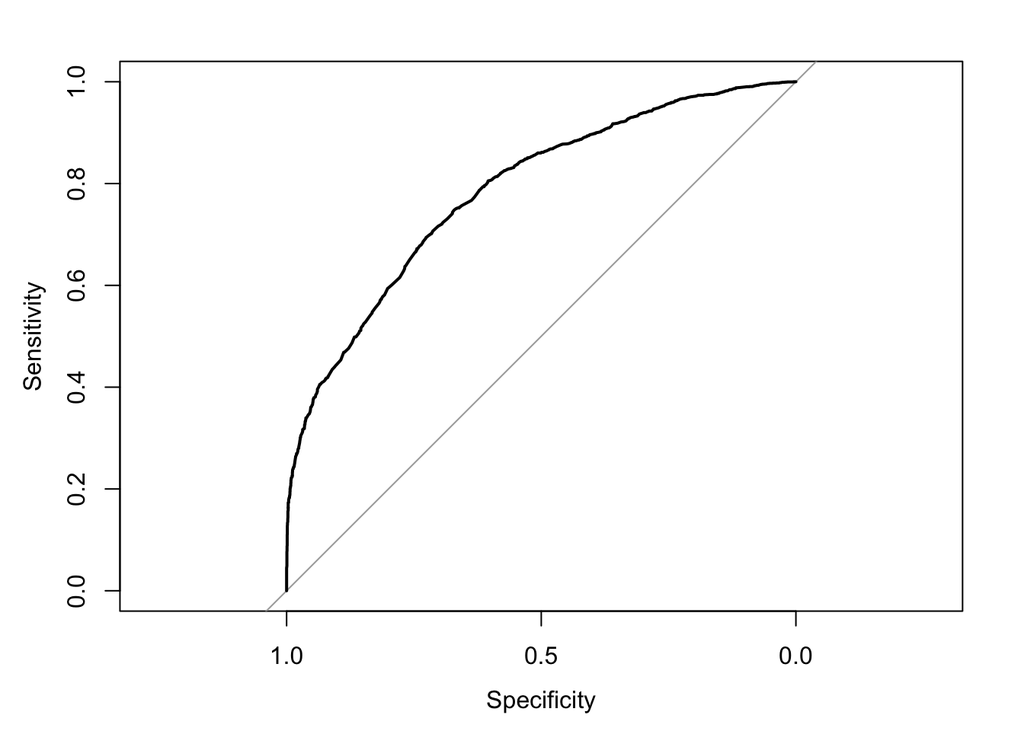

```r
plot(r)
```

```r
auc(r)
```

```
## Area under the curve: 0.7849
```

```r
best <- coords(r, "best", ret = c("threshold", "sensitivity", "specificity"), best.method = "youden")
best
```

```
##   threshold sensitivity specificity
## 1 0.4709976   0.6942482   0.7260857
```

### Deviance:

```r
p1 = pchisq(8958.7 - 7069.4, df = 40, lower.tail = FALSE)
p1
```

```
## [1] 0
```

## Logistic Regression Model 2:

### glm(property ~ multiple + attacktype1 + imonth, data = terror2019, family = binomial)

```r
library(stats)
model2 = glm(property ~ multiple + attacktype1 + imonth, data = terror2019, family = binomial)
summary(model2)
```

```
##
## Call:
## glm(formula = property ~ multiple + attacktype1 + imonth, family = binomial,
##     data = terror2019)
##
## Coefficients:
##               Estimate Std. Error z value Pr(>|z|)
## (Intercept)  -0.410395   0.122071  -3.362 0.000774 ***
## multiple1     0.507735   0.076872   6.605 3.98e-11 ***
## attacktype12 -0.098870   0.098928  -0.999 0.317592
## attacktype13  0.688196   0.093582   7.354 1.92e-13 ***
## attacktype14  1.852417   0.432918   4.279 1.88e-05 ***
## attacktype15  0.581868   0.291607   1.995 0.046001 *
## attacktype16 -0.791661   0.122557  -6.460 1.05e-10 ***
## attacktype17  3.902682   0.260800  14.964  < 2e-16 ***
## attacktype18 -0.518051   0.272975  -1.898 0.057723 .
## attacktype19 -0.812451   0.137053  -5.928 3.07e-09 ***
## imonth2      -0.354685   0.131737  -2.692 0.007095 **
## imonth3      -0.124127   0.128069  -0.969 0.332437
## imonth4      -0.560761   0.130598  -4.294 1.76e-05 ***
## imonth5      -0.103690   0.124093  -0.836 0.403391
## imonth6      -0.209982   0.133169  -1.577 0.114839
## imonth7       0.006808   0.130129   0.052 0.958276
## imonth8       0.078730   0.138414   0.569 0.569493
## imonth9       0.006876   0.139514   0.049 0.960693
## imonth10     -0.029567   0.142966  -0.207 0.836155
## imonth11     -0.023910   0.143941  -0.166 0.868068
## imonth12     -0.398258   0.135181  -2.946 0.003218 **
## ---
## Signif. codes:  0 '***' 0.001 '**' 0.01 '*' 0.05 '.' 0.1 ' ' 1
##
## (Dispersion parameter for binomial family taken to be 1)
##
##     Null deviance: 8958.7  on 6495  degrees of freedom
## Residual deviance: 7616.2  on 6475  degrees of freedom
## AIC: 7658.2
##
## Number of Fisher Scoring iterations: 6
```

### Accuracy:

```r
probs1 = predict(model2, type = "response")
pred1 = ifelse(probs1 > 0.5, 1, 0)
table(Predicted = pred1, Actual= terror2019$property)
```

```
##          Actual
## Predicted    0    1
##         0 2692 1298
##         1  831 1675
```

```r
mean(pred1 == terror2019$property)
```

```
## [1] 0.6722599
```

### ROC and AUC

```r
library(pROC)
probs1 = predict(model2, type = "response")
r = roc(terror2019$property, probs1)
```

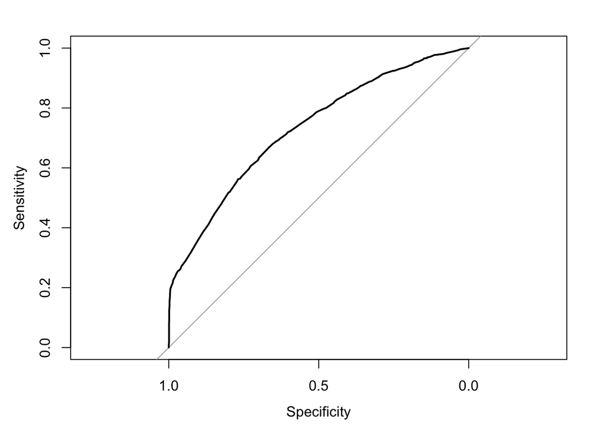

```r
plot(r)
```

```r
auc(r)
```

```
## Area under the curve: 0.7301
```

```r
best <- coords(r, "best", ret = c("threshold", "sensitivity", "specificity"), best.method = "youden")
best
```

```
##   threshold sensitivity specificity
## 1 0.4215844   0.6673394   0.6670451
```

### Deviance:

```r
p2 = pchisq(8958.7 - 7616.2, df = 20, lower.tail = FALSE)
p2
```

```
## [1] 2.332803e-272
```

Looking at each covariate it can be seen that not every type within a covariate is statistically significant. One example being that attack type three, four, five, six, seven and nine are statistically significant when compared to attack type one. However, attack type two and eight are not statistically significant compared to attack type one. Also, only month two, four, and twelve have statistical significance when compared to month one for this logistic regression model.

### Odds Ratio:

```r
exp(coef(model2))
```

```
##  (Intercept)    multiple1 attacktype12 attacktype13 attacktype14 attacktype15
##    0.6633884    1.6615234    0.9058603    1.9901227    6.3752086    1.7893778
## attacktype16 attacktype17 attacktype18 attacktype19      imonth2      imonth3
##    0.4530914   49.5351010    0.5956802    0.4437691    0.7013944    0.8832677
##      imonth4      imonth5      imonth6      imonth7      imonth8      imonth9
##    0.5707748    0.9015051    0.8105988    1.0068313    1.0819117    1.0068995
##     imonth10     imonth11     imonth12
##    0.9708654    0.9763731    0.6714888
```

Looking at the odds ratios of each coefficient it can be seen that some variables are above one, some below one, and some very close to one. This indicates for variables like multiple when compared to its reference variable has a sixty six percent increase in odds of property damage happening. While variables like month three when compared to its reference variable have a twelve percent decrease in odds of property damage happening.

## Logistic Regression Model 3(Just for comparison):

### glm(property ~ multiple + attacktype1, data = terror2019, family = binomial):

```r
library(stats)
model3 = glm(property ~ multiple + attacktype1, data = terror2019, family = binomial)
summary(model3)
```

```
##
## Call:
## glm(formula = property ~ multiple + attacktype1, family = binomial,
##     data = terror2019)
##
## Coefficients:
##              Estimate Std. Error z value Pr(>|z|)
## (Intercept)  -0.54690    0.08242  -6.635 3.24e-11 ***
## multiple1     0.50529    0.07618   6.633 3.29e-11 ***
## attacktype12 -0.11513    0.09834  -1.171   0.2417
## attacktype13  0.66815    0.09291   7.191 6.42e-13 ***
## attacktype14  1.85639    0.43056   4.312 1.62e-05 ***
## attacktype15  0.57643    0.29025   1.986   0.0470 *
## attacktype16 -0.79853    0.12183  -6.555 5.58e-11 ***
## attacktype17  3.88205    0.26038  14.909  < 2e-16 ***
## attacktype18 -0.49990    0.27146  -1.842   0.0655 .
## attacktype19 -0.87672    0.13618  -6.438 1.21e-10 ***
## ---
## Signif. codes:  0 '***' 0.001 '**' 0.01 '*' 0.05 '.' 0.1 ' ' 1
##
## (Dispersion parameter for binomial family taken to be 1)
##
##     Null deviance: 8958.7  on 6495  degrees of freedom
## Residual deviance: 7664.5  on 6486  degrees of freedom
## AIC: 7684.5
##
## Number of Fisher Scoring iterations: 6
```

### Accuracy:

```r
probs2 = predict(model3, type = "response")
pred2 = ifelse(probs2 > 0.5, 1, 0)
table(Predicted = pred2, Actual= terror2019$property)
```

```
##          Actual
## Predicted    0    1
##         0 2445 1097
##         1 1078 1876
```

```r
mean(pred2 == terror2019$property)
```

```
## [1] 0.6651786
```

### ROC and AUC:

```r
library(pROC)
probs2 = predict(model3, type = "response")
r = roc(terror2019$property, probs2)
```

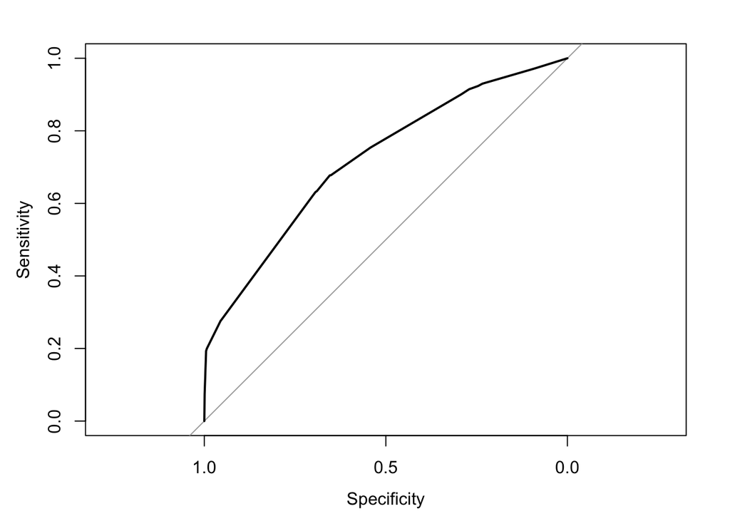

```r
plot(r)
```

```r
auc(r)
```

```
## Area under the curve: 0.7203
```

```r
best <- coords(r, "best", ret = c("threshold", "sensitivity", "specificity"), best.method = "youden")
best
```

```
##   threshold sensitivity specificity
## 1 0.4143667   0.6770938   0.6545558
```

### Deviance:

```r
p2 = pchisq(8958.7 - 7664.5, df = 11, lower.tail = FALSE)
p2
```

```
## [1] 7.972256e-271
```